# Exploring the 2012 PISA test results

## Preliminary Wrangling

> PISA is a survey of students' skills and knowledge as they approach the end of compulsory education. It is not a conventional school test. Rather than examining how well students have learned the school curriculum, it looks at how well prepared they are for life beyond school.

> Around 510,000 students in 65 economies took part in the PISA 2012 assessment of reading, mathematics and science representing about 28 million 15-year-olds globally. Of those economies, 44 took part in an assessment of creative problem solving and 18 in an assessment of financial literacy.

The data set can be downloaded [here](https://www.google.com/url?q=https://s3.amazonaws.com/udacity-hosted-downloads/ud507/pisa2012.csv.zip&sa=D&ust=1549035434262000)

```python
# import all packages and set plots to be embedded inline
import numpy as np
import pandas as pd
import matplotlib.pyplot as plt
import seaborn as sns

%matplotlib inline
```

### Importing the data sets and preliminary wrangling

Thanks [Balus1](https://stackoverflow.com/questions/2708958/differences-between-utf8-and-latin1) I was having difficulties importing the data set due to the encoding

```python
df = pd.read_csv('df_pisa2012.csv', encoding = 'latin1')
df.head()
```

|  | Unnamed: 0 | CNT | SUBNATIO | STRATUM | OECD | NC | SCHOOLID | STIDSTD | ST01Q01 | ST02Q01 | ... | W_FSTR75 | W_FSTR76 | W_FSTR77 | W_FSTR78 | W_FSTR79 | W_FSTR80 | WVARSTRR | VAR_UNIT | SENWGT_STU | VER_STU |
| --- | --- | --- | --- | --- | --- | --- | --- | --- | --- | --- | --- | --- | --- | --- | --- | --- | --- | --- | --- | --- | --- |
| 0 | 1 | Albania | 80000 | ALB0006 | Non-OECD | Albania | 1 | 1 | 10 | 1.0 | ... | 13.7954 | 13.9235 | 13.1249 | 13.1249 | 4.3389 | 13.0829 | 19 | 1 | 0.2098 | 22NOV13 |
| 1 | 2 | Albania | 80000 | ALB0006 | Non-OECD | Albania | 1 | 2 | 10 | 1.0 | ... | 13.7954 | 13.9235 | 13.1249 | 13.1249 | 4.3389 | 13.0829 | 19 | 1 | 0.2098 | 22NOV13 |
| 2 | 3 | Albania | 80000 | ALB0006 | Non-OECD | Albania | 1 | 3 | 9 | 1.0 | ... | 12.7307 | 12.7307 | 12.7307 | 12.7307 | 4.2436 | 12.7307 | 19 | 1 | 0.1999 | 22NOV13 |
| 3 | 4 | Albania | 80000 | ALB0006 | Non-OECD | Albania | 1 | 4 | 9 | 1.0 | ... | 12.7307 | 12.7307 | 12.7307 | 12.7307 | 4.2436 | 12.7307 | 19 | 1 | 0.1999 | 22NOV13 |
| 4 | 5 | Albania | 80000 | ALB0006 | Non-OECD | Albania | 1 | 5 | 9 | 1.0 | ... | 12.7307 | 12.7307 | 12.7307 | 12.7307 | 4.2436 | 12.7307 | 19 | 1 | 0.1999 | 22NOV13 |

5 rows × 636 columns

It seems that the column names are not very descriptive and there are way too many. I will make the dataframe shorter (less columns) and rename them

```python
data_dic = pd.read_csv('pisadict2012.csv', encoding = 'latin1')
#Change column names to pythonic convenntion
data_dic.rename(columns={'Acronym':'accronym','Explanation':'explanation'},inplace=True)
data_dic.head()
```

|  | accronym | explanation |
| --- | --- | --- |
| 0 | CNT | Country code 3-character |
| 1 | SUBNATIO | Adjudicated sub-region code 7-digit code (3-di... |
| 2 | STRATUM | Stratum ID 7-character (cnt + region ID + orig... |
| 3 | OECD | OECD country |
| 4 | NC | National Centre 6-digit Code |

I will change the names of the columns using the data_dic. Thanks [jezrael](https://stackoverflow.com/questions/44886974/renaming-of-columns-in-pandas-using-other-data-frame)

```python
d = data_dic.set_index(data_dic.columns[0])[data_dic.columns[1]].to_dict()
d
```

```
{'CNT': 'Country code 3-character',
 'SUBNATIO': 'Adjudicated sub-region code 7-digit code (3-digit country code + region ID + stratum ID)',
 'STRATUM': 'Stratum ID 7-character (cnt + region ID + original stratum ID)',
 'OECD': 'OECD country',
 'NC': 'National Centre 6-digit Code',
 'SCHOOLID': 'School ID 7-digit (region ID + stratum ID + 3-digit school ID)',
 'STIDSTD': 'Student ID',
 'ST01Q01': 'International Grade',
 'ST02Q01': 'National Study Programme',
 'ST03Q01': 'Birth - Month',
 'ST03Q02': 'Birth -Year',
 'ST04Q01': 'Gender',
 'ST05Q01': 'Attend <ISCED 0>',
 'ST06Q01': 'Age at <ISCED 1>',
 'ST07Q01': 'Repeat - <ISCED 1>',
 'ST07Q02': 'Repeat - <ISCED 2>',
 'ST07Q03': 'Repeat - <ISCED 3>',
 'ST08Q01': 'Truancy - Late for School',
 'ST09Q01': 'Truancy - Skip whole school day',
 'ST115Q01': 'Truancy - Skip classes within school day',
 'ST11Q01': 'At Home - Mother',
 'ST11Q02': 'At Home - Father',
 'ST11Q03': 'At Home - Brothers',
 'ST11Q04': 'At Home - Sisters',
 'ST11Q05': 'At Home - Grandparents',
 'ST11Q06': 'At Home - Others',
 'ST13Q01': 'Mother<Highest Schooling>',
 'ST14Q01': 'Mother Qualifications - <ISCED level 6>',
 'ST14Q02': 'Mother Qualifications - <ISCED level 5A>',
 'ST14Q03': 'Mother Qualifications - <ISCED level 5B>',
 'ST14Q04': 'Mother Qualifications - <ISCED level 4>',
 'ST15Q01': 'Mother Current Job Status',
 'ST17Q01': 'Father<Highest Schooling>',
 'ST18Q01': 'Father Qualifications - <ISCED level 6>',
 'ST18Q02': 'Father Qualifications - <ISCED level 5A>',
 'ST18Q03': 'Father Qualifications - <ISCED level 5B>',
 'ST18Q04': 'Father Qualifications - <ISCED level 4>',
 'ST19Q01': 'Father Current Job Status',
 'ST20Q01': 'Country of Birth International - Self',
 'ST20Q02': 'Country of Birth International - Mother',
```

[output cut: 580 more lines]

```
 'W_FSTR70': 'FINAL STUDENT REPLICATE BRR-FAY WEIGHT70',
 'W_FSTR71': 'FINAL STUDENT REPLICATE BRR-FAY WEIGHT71',
 'W_FSTR72': 'FINAL STUDENT REPLICATE BRR-FAY WEIGHT72',
 'W_FSTR73': 'FINAL STUDENT REPLICATE BRR-FAY WEIGHT73',
 'W_FSTR74': 'FINAL STUDENT REPLICATE BRR-FAY WEIGHT74',
 'W_FSTR75': 'FINAL STUDENT REPLICATE BRR-FAY WEIGHT75',
 'W_FSTR76': 'FINAL STUDENT REPLICATE BRR-FAY WEIGHT76',
 'W_FSTR77': 'FINAL STUDENT REPLICATE BRR-FAY WEIGHT77',
 'W_FSTR78': 'FINAL STUDENT REPLICATE BRR-FAY WEIGHT78',
 'W_FSTR79': 'FINAL STUDENT REPLICATE BRR-FAY WEIGHT79',
 'W_FSTR80': 'FINAL STUDENT REPLICATE BRR-FAY WEIGHT80',
 'WVARSTRR': 'RANDOMIZED FINAL VARIANCE STRATUM (1-80)',
 'VAR_UNIT': 'RANDOMLY ASSIGNED VARIANCE UNIT',
 'SENWGT_STU': 'Senate weight - sum of weight within the country is 1000',
 'VER_STU': 'Date of the database creation'}
```

Although many variables seem interesting, I will have to make choices on which variables I find most important. Here are some of them CNT, OECD SCHOOLID, STIDSTD, ST01Q01, ST03Q02, ST04Q01, ST20Q01, ST43Q02, GRADE, HISCED, ST49Q05, ST49Q06, ST49Q03, TIMEINT, PV1MATH, PV1READ, PV1SCIEW_FSTUWT

```python
#Backup data frame
df1 = df.copy()
```

```python
columns_a = ['CNT','OECD', 'SCHOOLID','STIDSTD','ST01Q01','ST03Q02','ST04Q01','ST43Q02','ST20Q01','GRADE','HISCED','ST49Q05','ST49Q06','ST49Q03','TIMEINT','PV1MATH','PV1READ','PV1SCIE','W_FSTUWT']
df1 = df1[columns_a]
df1.shape
```

```
(485490, 19)
```

```python
df1.rename(columns = d)
```

|  | Country code 3-character | OECD country | School ID 7-digit (region ID + stratum ID + 3-digit school ID) | Student ID | International Grade | Birth -Year | Gender | Perceived Control - Doing Well is Completely Up to Me | Country of Birth International - Self | Grade compared to modal grade in country | Highest educational level of parents | Math Behaviour - Study More Than 2 Extra Hours a Day | Math Behaviour - Play Chess | Math Behaviour - <Extracurricular> Activity | Time of computer use (mins) | Plausible value 1 in mathematics | Plausible value 1 in reading | Plausible value 1 in science | FINAL STUDENT WEIGHT |
| --- | --- | --- | --- | --- | --- | --- | --- | --- | --- | --- | --- | --- | --- | --- | --- | --- | --- | --- | --- |
| 0 | Albania | Non-OECD | 1 | 1 | 10 | 1996 | Female | Disagree | Country of test | 0.0 | ISCED 3A, ISCED 4 | Sometimes | Never or rarely | Sometimes | NaN | 406.8469 | 249.5762 | 341.7009 | 8.9096 |
| 1 | Albania | Non-OECD | 1 | 2 | 10 | 1996 | Female | Strongly agree | Country of test | 0.0 | ISCED 5A, 6 | Always or almost always | Never or rarely | Always or almost always | NaN | 486.1427 | 406.2936 | 548.9929 | 8.9096 |
| 2 | Albania | Non-OECD | 1 | 3 | 9 | 1996 | Female | Agree | Country of test | -1.0 | ISCED 5A, 6 | Always or almost always | Never or rarely | Sometimes | NaN | 533.2684 | 401.2100 | 499.6643 | 8.4871 |
| 3 | Albania | Non-OECD | 1 | 4 | 9 | 1996 | Female | NaN | Country of test | -1.0 | ISCED 5A, 6 | NaN | NaN | NaN | NaN | 412.2215 | 547.3630 | 438.6796 | 8.4871 |
| 4 | Albania | Non-OECD | 1 | 5 | 9 | 1996 | Female | Strongly agree | Country of test | -1.0 | ISCED 3A, ISCED 4 | Sometimes | NaN | Often | NaN | 381.9209 | 311.7707 | 361.5628 | 8.4871 |
| 5 | Albania | Non-OECD | 1 | 6 | 9 | 1996 | Female | NaN | Country of test | -1.0 | ISCED 3B, C | NaN | NaN | NaN | NaN | 396.3312 | 378.2544 | 384.3156 | 8.4871 |
| 6 | Albania | Non-OECD | 1 | 7 | 10 | 1996 | Female | NaN | Country of test | 0.0 | ISCED 5A, 6 | NaN | NaN | NaN | NaN | 438.0823 | 373.2503 | 508.1499 | 8.9096 |
| 7 | Albania | Non-OECD | 1 | 8 | 10 | 1996 | Male | Agree | Country of test | 0.0 | ISCED 5A, 6 | Sometimes | NaN | Sometimes | NaN | 576.5773 | 567.7589 | 611.2831 | 9.8606 |
| 8 | Albania | Non-OECD | 1 | 9 | 9 | 1996 | Female | Strongly agree | Country of test | -1.0 | ISCED 5A, 6 | Never or rarely | Never or rarely | Sometimes | NaN | 434.1097 | 313.9153 | 373.0325 | 8.4871 |
| 9 | Albania | Non-OECD | 2 | 10 | 10 | 1996 | Female | NaN | Country of test | 0.0 | ISCED 3A, ISCED 4 | NaN | NaN | NaN | NaN | 463.6314 | 454.5082 | 404.2708 | 6.7688 |
| 10 | Albania | Non-OECD | 2 | 11 | 10 | 1996 | Female | NaN | Country of test | 0.0 | ISCED 5A, 6 | NaN | NaN | NaN | NaN | 403.8869 | 550.0637 | 438.0269 | 6.7688 |
| 11 | Albania | Non-OECD | 2 | 12 | 10 | 1996 | Female | Strongly agree | Country of test | 0.0 | ISCED 3A, ISCED 4 | Never or rarely | Often | Sometimes | NaN | 281.2821 | 229.1624 | 340.1156 | 6.7688 |
| 12 | Albania | Non-OECD | 2 | 13 | 10 | 1996 | Female | Strongly agree | Country of test | 0.0 | ISCED 2 | Always or almost always | Always or almost always | NaN | NaN | 244.8279 | 162.9964 | 150.5408 | 6.7688 |
| 13 | Albania | Non-OECD | 2 | 14 | 10 | 1996 | Female | Strongly agree | Country of test | 0.0 | ISCED 3A, ISCED 4 | Never or rarely | Never or rarely | Sometimes | NaN | 485.5974 | 563.0904 | 489.5002 | 6.7688 |
| 14 | Albania | Non-OECD | 2 | 15 | 10 | 1996 | Male | Agree | Country of test | 0.0 | ISCED 5A, 6 | Often | Sometimes | Often | NaN | 356.1380 | 259.8119 | 264.5841 | 7.4167 |
| 15 | Albania | Non-OECD | 2 | 16 | 10 | 1996 | Male | Agree | Country of test | 0.0 | ISCED 5A, 6 | Always or almost always | Sometimes | Always or almost always | NaN | 381.2977 | 376.3346 | 402.5923 | 7.4167 |
| 16 | Albania | Non-OECD | 2 | 17 | 10 | 1996 | Female | Agree | NaN | 0.0 | ISCED 3A, ISCED 4 | Often | Never or rarely | Often | NaN | 246.3078 | 194.7688 | 145.2257 | 6.7688 |
| 17 | Albania | Non-OECD | 2 | 18 | 10 | 1996 | Male | NaN | Country of test | 0.0 | ISCED 2 | NaN | NaN | NaN | NaN | 528.3611 | 566.1550 | 511.0407 | 7.4167 |
| 18 | Albania | Non-OECD | 2 | 19 | 10 | 1996 | Female | NaN | Country of test | 0.0 | ISCED 5A, 6 | NaN | NaN | NaN | NaN | 384.2577 | 362.6065 | 350.3730 | 6.7688 |
| 19 | Albania | Non-OECD | 2 | 20 | 10 | 1996 | Female | NaN | Country of test | 0.0 | ISCED 3A, ISCED 4 | NaN | NaN | NaN | NaN | 450.0779 | 475.1603 | 509.2689 | 6.7688 |
| 20 | Albania | Non-OECD | 2 | 21 | 10 | 1996 | Female | Agree | Country of test | 0.0 | ISCED 5A, 6 | Often | Sometimes | Sometimes | NaN | 369.4579 | 410.2651 | 356.9004 | 6.7688 |
| 21 | Albania | Non-OECD | 2 | 22 | 10 | 1996 | Male | Agree | Country of test | 0.0 | ISCED 3A, ISCED 4 | Often | Sometimes | Never or rarely | NaN | 370.4705 | 459.4161 | 371.9135 | 7.4167 |
| 22 | Albania | Non-OECD | 2 | 23 | 10 | 1996 | Female | Strongly agree | Country of test | 0.0 | ISCED 2 | Sometimes | Sometimes | Often | NaN | 132.5830 | 258.2342 | 277.3592 | 6.7688 |
| 23 | Albania | Non-OECD | 2 | 24 | 10 | 1996 | Female | Strongly agree | Country of test | 0.0 | ISCED 5B | Always or almost always | Sometimes | Often | NaN | 508.0308 | 392.4726 | 468.5192 | 6.7688 |
| 24 | Albania | Non-OECD | 2 | 25 | 10 | 1996 | Male | NaN | Country of test | 0.0 | ISCED 2 | Never or rarely | Always or almost always | Never or rarely | NaN | 295.1472 | 317.4718 | 315.8709 | 7.4167 |
| 25 | Albania | Non-OECD | 2 | 26 | 10 | 1996 | Female | Strongly agree | Country of test | 0.0 | ISCED 3A, ISCED 4 | Never or rarely | Never or rarely | Sometimes | NaN | 353.5675 | 345.6083 | 349.4405 | 6.7688 |
| 26 | Albania | Non-OECD | 2 | 27 | 10 | 1996 | Female | NaN | Country of test | 0.0 | ISCED 5A, 6 | NaN | NaN | NaN | NaN | 376.3904 | 388.5805 | 361.5628 | 6.7688 |
| 27 | Albania | Non-OECD | 2 | 28 | 10 | 1996 | Male | Strongly agree | Country of test | 0.0 | ISCED 5A, 6 | Never or rarely | Sometimes | Sometimes | NaN | 434.1097 | 466.7138 | 459.1943 | 7.4167 |
| 28 | Albania | Non-OECD | 2 | 29 | 10 | 1996 | Female | Strongly agree | Country of test | 0.0 | ISCED 2 | Never or rarely | Often | Sometimes | NaN | 328.0963 | 365.5455 | 268.1276 | 6.7688 |
| 29 | Albania | Non-OECD | 2 | 30 | 10 | 1996 | Female | NaN | Country of test | 0.0 | ISCED 5A, 6 | NaN | NaN | NaN | NaN | 554.6892 | 569.1271 | 542.4655 | 6.7688 |
| ... | ... | ... | ... | ... | ... | ... | ... | ... | ... | ... | ... | ... | ... | ... | ... | ... | ... | ... | ... |
| 485460 | Vietnam | Non-OECD | 162 | 4930 | 10 | 1996 | Male | NaN | Country of test | 0.0 | ISCED 1 | NaN | NaN | NaN | NaN | 490.8942 | 457.8924 | 524.7482 | 65.7647 |
| 485461 | Vietnam | Non-OECD | 162 | 4931 | 10 | 1996 | Male | Strongly agree | Country of test | 0.0 | None | Sometimes | Sometimes | Often | NaN | 556.3250 | 477.2995 | 550.8579 | 65.7647 |
| 485462 | Vietnam | Non-OECD | 162 | 4932 | 10 | 1996 | Female | Disagree | Country of test | 0.0 | None | Never or rarely | Never or rarely | Sometimes | NaN | 450.4674 | 524.4075 | 549.8322 | 62.4825 |
| 485463 | Vietnam | Non-OECD | 162 | 4933 | 10 | 1996 | Male | Agree | Country of test | 0.0 | ISCED 5A, 6 | Sometimes | Often | Never or rarely | NaN | 512.3929 | 462.5437 | 549.9254 | 65.7647 |
| 485464 | Vietnam | Non-OECD | 162 | 4934 | 10 | 1996 | Male | Agree | Country of test | 0.0 | ISCED 2 | Sometimes | Sometimes | Never or rarely | NaN | 543.5504 | 524.4538 | 540.6005 | 65.7647 |
| 485465 | Vietnam | Non-OECD | 162 | 4935 | 10 | 1996 | Male | NaN | Country of test | 0.0 | None | NaN | NaN | NaN | NaN | 529.8411 | 536.6434 | 599.1608 | 65.7647 |
| 485466 | Vietnam | Non-OECD | 162 | 4936 | 10 | 1996 | Male | Agree | Country of test | 0.0 | None | Sometimes | Often | Sometimes | NaN | 462.2293 | 423.0880 | 512.2529 | 65.7647 |
| 485467 | Vietnam | Non-OECD | 162 | 4937 | 10 | 1996 | Female | Agree | Country of test | 0.0 | ISCED 1 | Sometimes | Never or rarely | Sometimes | NaN | 436.4465 | 475.2397 | 457.8888 | 62.4825 |
| 485468 | Vietnam | Non-OECD | 162 | 4938 | 10 | 1996 | Female | NaN | Country of test | 0.0 | ISCED 1 | NaN | NaN | NaN | NaN | 510.5234 | 453.3962 | 575.6621 | 62.4825 |
| 485469 | Vietnam | Non-OECD | 162 | 4939 | 10 | 1996 | Female | Agree | Country of test | 0.0 | None | Never or rarely | Sometimes | Sometimes | NaN | 414.7920 | 456.0968 | 527.2659 | 62.4825 |
| 485470 | Vietnam | Non-OECD | 162 | 4940 | 10 | 1996 | Male | Agree | Country of test | 0.0 | ISCED 1 | Sometimes | Never or rarely | Sometimes | NaN | 421.5688 | 399.3504 | 467.8665 | 65.7647 |
| 485471 | Vietnam | Non-OECD | 162 | 4941 | 10 | 1996 | Male | Agree | Country of test | 0.0 | ISCED 3A, ISCED 4 | Never or rarely | Never or rarely | Never or rarely | NaN | 503.2793 | 548.4320 | 552.7229 | 65.7647 |
| 485472 | Vietnam | Non-OECD | 162 | 4942 | 10 | 1996 | Male | NaN | Country of test | 0.0 | ISCED 1 | NaN | NaN | NaN | NaN | 559.9081 | 486.6020 | 569.5076 | 65.7647 |
| 485473 | Vietnam | Non-OECD | 162 | 4943 | 10 | 1996 | Female | Agree | Country of test | 0.0 | ISCED 2 | Never or rarely | Never or rarely | Sometimes | NaN | 458.9578 | 443.3879 | 456.6766 | 62.4825 |
| 485474 | Vietnam | Non-OECD | 162 | 4944 | 10 | 1996 | Male | Strongly agree | Country of test | 0.0 | ISCED 2 | Sometimes | Never or rarely | Sometimes | NaN | 373.2747 | 418.7575 | 481.6673 | 65.7647 |
| 485475 | Vietnam | Non-OECD | 162 | 4945 | 10 | 1996 | Male | NaN | Country of test | 0.0 | None | NaN | NaN | NaN | NaN | 439.1728 | 481.9507 | 494.9086 | 65.7647 |
| 485476 | Vietnam | Non-OECD | 162 | 4946 | 10 | 1996 | Female | NaN | Country of test | 0.0 | ISCED 2 | NaN | NaN | NaN | NaN | 463.7093 | 493.4294 | 491.0854 | 62.4825 |
| 485477 | Vietnam | Non-OECD | 162 | 4947 | 10 | 1996 | Female | Strongly agree | Country of test | 0.0 | ISCED 1 | Never or rarely | Sometimes | Never or rarely | NaN | 486.4543 | 530.7620 | 503.3010 | 62.4825 |
| 485478 | Vietnam | Non-OECD | 162 | 4948 | 10 | 1996 | Female | NaN | Country of test | 0.0 | ISCED 1 | NaN | NaN | NaN | NaN | 439.7959 | 442.7524 | 485.2107 | 62.4825 |
| 485479 | Vietnam | Non-OECD | 162 | 4949 | 10 | 1996 | Male | NaN | Country of test | 0.0 | ISCED 5A, 6 | NaN | NaN | NaN | NaN | 426.4761 | 418.5971 | 473.1816 | 65.7647 |
| 485480 | Vietnam | Non-OECD | 162 | 4950 | 10 | 1996 | Male | Strongly agree | Country of test | 0.0 | ISCED 5A, 6 | Never or rarely | Never or rarely | Never or rarely | NaN | 432.7855 | 452.4392 | 547.6874 | 65.7647 |
| 485481 | Vietnam | Non-OECD | 162 | 4951 | 10 | 1996 | Male | NaN | Country of test | 0.0 | ISCED 3A, ISCED 4 | NaN | NaN | NaN | NaN | 387.2176 | 459.4161 | 473.4614 | 65.7647 |
| 485482 | Vietnam | Non-OECD | 162 | 4952 | 10 | 1996 | Female | Strongly agree | Country of test | 0.0 | ISCED 3A, ISCED 4 | Sometimes | Sometimes | Sometimes | NaN | 459.4251 | 509.3156 | 477.1913 | 62.4825 |
| 485483 | Vietnam | Non-OECD | 162 | 4953 | 10 | 1996 | Female | NaN | Country of test | 0.0 | ISCED 3A, ISCED 4 | NaN | NaN | NaN | NaN | 526.1022 | 482.3090 | 533.4204 | 62.4825 |
| 485484 | Vietnam | Non-OECD | 162 | 4954 | 10 | 1996 | Male | Strongly agree | Country of test | 0.0 | ISCED 1 | Often | Sometimes | Often | NaN | 500.4752 | 433.8340 | 480.6416 | 65.7647 |
| 485485 | Vietnam | Non-OECD | 162 | 4955 | 10 | 1996 | Female | Agree | Country of test | 0.0 | ISCED 2 | Sometimes | Sometimes | Never or rarely | NaN | 477.1849 | 460.2272 | 559.8098 | 62.4825 |
| 485486 | Vietnam | Non-OECD | 162 | 4956 | 10 | 1996 | Male | Agree | Country of test | 0.0 | ISCED 2 | Never or rarely | Never or rarely | Never or rarely | NaN | 518.9360 | 490.9325 | 538.7355 | 65.7647 |
| 485487 | Vietnam | Non-OECD | 162 | 4957 | 10 | 1996 | Male | Agree | Country of test | 0.0 | ISCED 2 | Sometimes | Often | Sometimes | NaN | 475.2376 | 462.6239 | 536.8706 | 65.7647 |
| 485488 | Vietnam | Non-OECD | 162 | 4958 | 10 | 1996 | Male | NaN | Country of test | 0.0 | ISCED 5A, 6 | NaN | NaN | NaN | NaN | 550.9503 | 505.2873 | 511.0407 | 65.7647 |
| 485489 | Vietnam | Non-OECD | 162 | 4959 | 10 | 1996 | Female | Strongly agree | Country of test | 0.0 | ISCED 3A, ISCED 4 | Sometimes | Never or rarely | Sometimes | NaN | 470.0187 | 532.3506 | 530.6229 | 62.4825 |

485490 rows × 19 columns

Names are not too easy. Lets change that

```python
aa = df1.columns
for a in aa:
    print(a,':', d[a])
```

```
CNT : Country code 3-character
OECD : OECD country
SCHOOLID : School ID 7-digit (region ID + stratum ID + 3-digit school ID)
STIDSTD : Student ID
ST01Q01 : International Grade
ST03Q02 : Birth -Year
ST04Q01 : Gender
ST43Q02 : Perceived Control - Doing Well is Completely Up to Me
ST20Q01 : Country of Birth International - Self
GRADE : Grade compared to modal grade in country
HISCED : Highest educational level of parents
ST49Q05 : Math Behaviour - Study More Than 2 Extra Hours a Day
ST49Q06 : Math Behaviour - Play Chess
ST49Q03 : Math Behaviour - <Extracurricular> Activity
TIMEINT : Time of computer use (mins)
PV1MATH : Plausible value 1 in mathematics
PV1READ : Plausible value 1 in reading
PV1SCIE : Plausible value 1 in science
W_FSTUWT : FINAL STUDENT WEIGHT
```

```python
new_columns = {'CNT':'country',
               'STIDSTD':'student_id',
               'ST01Q01':'int_grade',
               'OECD': 'oecd',
               'SCHOOLID':'school_id',
               'ST03Q02':'birth_year',
               'ST04Q01':'gender',
               'ST43Q02':'agency',
               'ST20Q01':'country_birth',
               'GRADE': 'grade',
               'HISCED':'parents_ed',
              'ST49Q05': 'two_hours_math',
              'ST49Q06': 'play_chess',
              'ST49Q03':'extracurricular_math',
              'TIMEINT':'computer_time',
                'PV1MATH':'math_score',
              'PV1READ' : 'reading_score',
              'PV1SCIE': 'science_score',
              'W_FSTUWT':'final_weight'}
```

```python
df1.rename(columns = new_columns, inplace=True)
df1.sample()
```

|  | country | oecd | school_id | student_id | int_grade | birth_year | gender | agency | country_birth | grade | parents_ed | two_hours_math | play_chess | extracurricular_math | computer_time | math_score | reading_score | science_score | final_weight |
| --- | --- | --- | --- | --- | --- | --- | --- | --- | --- | --- | --- | --- | --- | --- | --- | --- | --- | --- | --- |
| 235128 | Iceland | OECD | 120 | 3102 | 10 | 1996 | Female | Disagree | Country of test | 0.0 | ISCED 5A, 6 | Never or rarely | Never or rarely | Sometimes | 45.0 | 562.4786 | 618.3744 | 641.3092 | 1.25 |

Countries names need a little wrangling first

```python
df1.country.value_counts().reset_index()['index'].tolist()
```

```
['Mexico',
 'Italy',
 'Spain',
 'Canada',
 'Brazil',
 'Australia',
 'United Kingdom',
 'United Arab Emirates',
 'Switzerland',
 'Qatar',
 'Colombia',
 'Finland',
 'Belgium',
 'Denmark',
 'Jordan',
 'Chile',
 'Thailand',
 'Japan',
 'Chinese Taipei',
 'Peru',
 'Slovenia',
 'Argentina',
 'Kazakhstan',
 'Portugal',
 'Indonesia',
 'Singapore',
 'Macao-China',
 'Czech Republic',
 'Uruguay',
 'Bulgaria',
 'Luxembourg',
 'Russian Federation',
 'Malaysia',
 'China-Shanghai',
 'Greece',
 'Romania',
 'Israel',
 'Korea',
 'Ireland',
 'Croatia',
```

[output cut: 13 more lines]

```
 'Hong Kong-China',
 'Lithuania',
 'France',
 'Poland',
 'Costa Rica',
 'Netherlands',
 'Tunisia',
 'Latvia',
 'New Zealand',
 'Iceland',
 'Florida (USA)',
 'Perm(Russian Federation)',
 'Massachusetts (USA)',
 'Connecticut (USA)',
 'Liechtenstein']
```

```python
new_countries = {'Chinese Taipei':'Taiwan',
                 'Russian Federation':'Russia',
                 'United States of America':'USA',
                 'Florida (USA)': 'USA',
                 'Massachusetts (USA)':'USA',
                 'Connecticut (USA)': 'USA',
                 'Perm(Russian Federation)': 'Russia'}
```

```python
df1['country'].replace(new_countries,inplace=True)
```

```python
df1.describe()
```

|  | school_id | student_id | int_grade | birth_year | grade | computer_time | math_score | reading_score | science_score | final_weight |
| --- | --- | --- | --- | --- | --- | --- | --- | --- | --- | --- |
| count | 485490.000000 | 485490.000000 | 485490.000000 | 485490.000000 | 484617.000000 | 297074.000000 | 485490.000000 | 485490.000000 | 485490.000000 | 485490.000000 |
| mean | 240.152197 | 6134.066201 | 9.813323 | 1996.070061 | -0.162964 | 50.895996 | 469.621653 | 472.004640 | 475.769824 | 50.919113 |
| std | 278.563016 | 6733.144944 | 3.734726 | 0.255250 | 0.655558 | 40.987895 | 103.265391 | 102.505523 | 101.464426 | 107.382092 |
| min | 1.000000 | 1.000000 | 7.000000 | 1996.000000 | -3.000000 | 0.000000 | 19.792800 | 0.083400 | 2.648300 | 1.000000 |
| 25% | 61.000000 | 1811.000000 | 9.000000 | 1996.000000 | 0.000000 | 19.000000 | 395.318600 | 403.600700 | 404.457300 | 6.386300 |
| 50% | 136.000000 | 3740.000000 | 10.000000 | 1996.000000 | 0.000000 | 39.000000 | 466.201900 | 475.455000 | 475.699400 | 15.782900 |
| 75% | 291.000000 | 7456.000000 | 10.000000 | 1996.000000 | 0.000000 | 71.000000 | 541.057800 | 544.502500 | 547.780700 | 44.473300 |
| max | 1471.000000 | 33806.000000 | 96.000000 | 1997.000000 | 3.000000 | 206.000000 | 962.229300 | 904.802600 | 903.338300 | 2597.884400 |

```python
#Backup of reduced dataframe
df2 = df1.copy()
```

## Univariate Exploration

The objective of this analysis is ultimately to understand the relationship between several variables (Xis) and the PISA test scores (Yis). Let's explore:

- Distribution of scores (math, reading, science)
- Countries
- Age
- Computer usage
- Math practice

### Visualizing Score distribution

```python
# Determine correct bin size
step = 50
bins = np.arange(0,df2.math_score.max() + step, step)
```

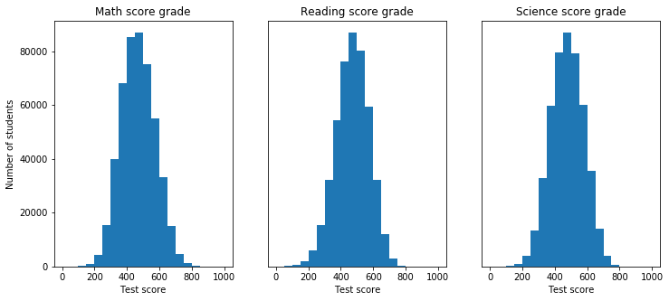

```python
# Plotting the distribution of scores
plt.figure(figsize=[12,5])

plt.subplot(1,3,1)
plt.hist(df2.math_score, bins = bins)
plt.title('Math score grade')
plt.ylabel('Number of students')
plt.xlabel('Test score')

plt.subplot(1,3,2)
plt.hist(df2.reading_score, bins = bins)
plt.yticks([])
plt.title('Reading score grade')
plt.xlabel('Test score')


plt.subplot(1,3,3)
plt.hist(df2.science_score, bins = bins)
plt.yticks([])
plt.title('Science score grade')
plt.xlabel('Test score');
```

The data seems to be normally distributed with the mean around 500

### Where do y'all come from? - Visualizing countries

> Make sure that, after every plot or related series of plots, that you include a Markdown cell with comments about what you observed, and what you plan on investigating next.

We don't have continents in the data set but let's add some. I found [this csv on github](https://github.com/dbouquin/IS_608/blob/master/NanosatDB_munging/Countries-Continents.csv) with the list of continents and countries.

```python
continents = pd.read_csv('continents.csv')
continents.sample()
```

|  | continent | country |
| --- | --- | --- |
| 128 | Europe | Monaco |

Let's add the continent column to our dataframe

```python
df2 = pd.merge(df2,continents, on='country',how='left')
df2.sample()
```

|  | country | oecd | school_id | student_id | int_grade | birth_year | gender | agency | country_birth | grade | parents_ed | two_hours_math | play_chess | extracurricular_math | computer_time | math_score | reading_score | science_score | final_weight | continent |
| --- | --- | --- | --- | --- | --- | --- | --- | --- | --- | --- | --- | --- | --- | --- | --- | --- | --- | --- | --- | --- |
| 473989 | Uruguay | Non-OECD | 122 | 3752 | 8 | 1997 | Male | Strongly agree | Country of test | -2.0 | ISCED 2 | Never or rarely | Always or almost always | Sometimes | 206.0 | 385.1145 | 348.5071 | 314.5655 | 6.0092 | South America |

Just for the aesthethics, let's reorder the columns so that country and continent are close by

```python
df2.columns.tolist()
```

```
['country',
 'oecd',
 'school_id',
 'student_id',
 'int_grade',
 'birth_year',
 'gender',
 'agency',
 'country_birth',
 'grade',
 'parents_ed',
 'two_hours_math',
 'play_chess',
 'extracurricular_math',
 'computer_time',
 'math_score',
 'reading_score',
 'science_score',
 'final_weight',
 'continent']
```

```python
col_reor = ['country',
            'continent',
            'country_birth',
 'oecd',
 'school_id',
 'student_id',
 'int_grade',
 'birth_year',
 'gender',
 'agency',
 'grade',
 'parents_ed',
 'two_hours_math',
 'play_chess',
 'extracurricular_math',
 'computer_time',
 'math_score',
 'reading_score',
 'science_score',
 'final_weight']
```

After some data wrangling, finally time for some visualizations!

```python
base_color = sns.color_palette()[0]
```

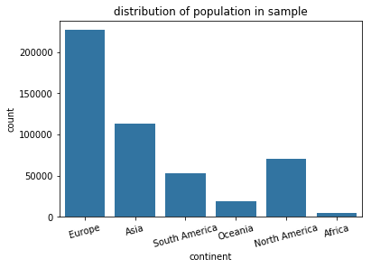

```python
sns.countplot(df2.continent, color = base_color)
plt.xticks(rotation = 15)
plt.title('distribution of population in sample');
```

This distribution suggests that Europe has the highest representation, whereas Oceania and Africa have very low proportional representation in this data set, so we should treat the results with caution

### Other explorations

How many minutes per deay are the test takers using computers?

```
Text(0.5,1,'Min per day spent on computer')
```

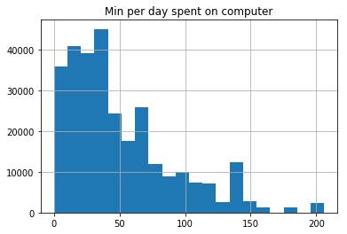

```python
df2.computer_time.hist(bins = 20)
plt.title('Min per day spent on computer')
```

How much math are the students practicing?

```python
df2.extracurricular_math.value_counts()
```

```
Never or rarely            160292
Sometimes                   92310
Often                       41786
Always or almost always     17780
Name: extracurricular_math, dtype: int64
```

```python
xorder = ['Always or almost always', 'Often', 'Sometimes', 'Never or rarely']
```

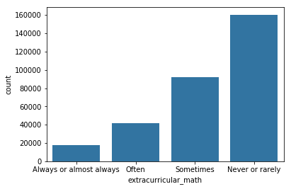

```python
sns.countplot(data = df2, x='extracurricular_math', color = base_color, order = xorder)
```

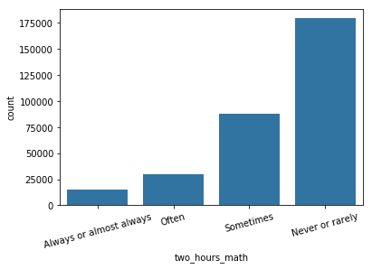

```python
sns.countplot(data = df2, x='two_hours_math', color = base_color, order = xorder)
plt.xticks(rotation =  15);
```

As could be expected, the distribution of people who do extracurricular math and those who spend at least 2 hours a day doing math are similarly distributed. But are they correlated with each other?

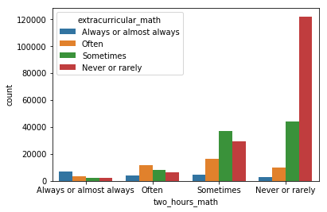

```python
sns.countplot(data = df2, x = 'two_hours_math', hue = 'extracurricular_math', hue_order = xorder, order = xorder );
```

It seems that indeed they are correlated, although to a lesser extent than one might think, i.e. from those who never or rarely do at least two hours of math a day, most of them do not do any extracurricular math

## Bivariate Exploration

> In this section, investigate relationships between pairs of variables in your data. Make sure the variables that you cover here have been introduced in some fashion in the previous section (univariate exploration).

### What variables can influence test scores?

```python
df2['average_score'] = df2[['math_score', 'reading_score', 'science_score']].mean(axis=1)
df_top10 = df2.nlargest(20,'average_score')
```

```python
df2.info()
```

```
<class 'pandas.core.frame.DataFrame'>
Int64Index: 485490 entries, 0 to 485489
Data columns (total 21 columns):
country                 485490 non-null object
oecd                    485490 non-null object
school_id               485490 non-null int64
student_id              485490 non-null int64
int_grade               485490 non-null int64
birth_year              485490 non-null int64
gender                  485490 non-null object
agency                  314182 non-null object
country_birth           476363 non-null object
grade                   484617 non-null float64
parents_ed              473091 non-null object
two_hours_math          312582 non-null object
play_chess              312571 non-null object
extracurricular_math    312168 non-null object
computer_time           297074 non-null float64
math_score              485490 non-null float64
reading_score           485490 non-null float64
science_score           485490 non-null float64
final_weight            485490 non-null float64
continent               485490 non-null object
average_score           485490 non-null float64
dtypes: float64(7), int64(4), object(10)
memory usage: 101.5+ MB
```

### Score and geographies: Do the PISA scores vary by region?

```python
cont_order = df2.groupby('continent')['math_score'].mean().sort_values(ascending=False).reset_index()['continent'].tolist()
```

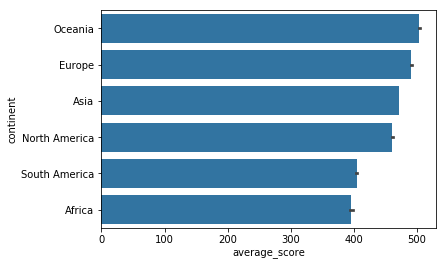

```python
sns.barplot(data = df2, x = 'average_score', y='continent', color = base_color, order = cont_order);
```

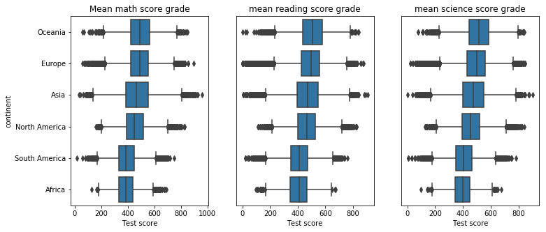

```python
plt.figure(figsize=[12,5])

plt.subplot(1,3,1)
sns.boxplot(data = df2, x = 'math_score', y='continent', color = base_color, order = cont_order)
plt.title('Mean math score grade')
plt.xlabel('Test score')

plt.subplot(1,3,2)
sns.boxplot(data = df2, x = 'reading_score', y='continent', color = base_color, order = cont_order)
plt.yticks([])
plt.ylabel('')
plt.title('mean reading score grade')
plt.xlabel('Test score')


plt.subplot(1,3,3)
sns.boxplot(data = df2, x = 'science_score', y='continent', color = base_color, order = cont_order)
plt.yticks([])
plt.title('mean science score grade')
plt.xlabel('Test score')
plt.ylabel('');
```

It would seem that if we look at entire continents, the continent with the highest test scores accross all 3 categories are those students from Oceania. Impressive! Meanwhile, South America and Africa seem to be the lowest performing students

Do students from OECD countries do significantly better than non-OECD?

```
Text(0.5,0,'Test score')
```

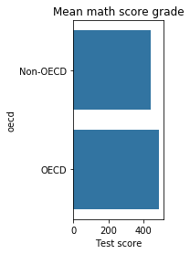

```python
plt.subplot(1,3,1)
sns.barplot(data = df2, x = 'math_score', y='oecd', color = base_color)
plt.title('Mean math score grade')
plt.xlabel('Test score')
```

```python
df2.sample(4)
```

|  | country | oecd | school_id | student_id | int_grade | birth_year | gender | agency | country_birth | grade | ... | two_hours_math | play_chess | extracurricular_math | computer_time | math_score | reading_score | science_score | final_weight | continent | average_score |
| --- | --- | --- | --- | --- | --- | --- | --- | --- | --- | --- | --- | --- | --- | --- | --- | --- | --- | --- | --- | --- | --- |
| 404245 | China-Shanghai | Non-OECD | 121 | 4029 | 10 | 1996 | Female | NaN | Country of test | 0.0 | ... | NaN | NaN | NaN | 30.0 | 631.5703 | 590.3352 | 586.6654 | 16.8222 | Asia | 602.856967 |
| 251362 | Italy | OECD | 413 | 10773 | 10 | 1996 | Female | NaN | Country of test | 0.0 | ... | NaN | NaN | NaN | 21.0 | 593.0908 | 498.0364 | 616.0388 | 9.3703 | Europe | 569.055333 |
| 309642 | Latvia | Non-OECD | 173 | 3581 | 9 | 1996 | Male | Agree | Country of test | 0.0 | ... | Sometimes | Never or rarely | Never or rarely | 111.0 | 420.8677 | 441.2921 | 425.9045 | 3.2143 | Europe | 429.354767 |
| 62899 | Brazil | Non-OECD | 340 | 7634 | 10 | 1996 | Male | Agree | Country of test | -1.0 | ... | Never or rarely | Never or rarely | Sometimes | NaN | 372.4178 | 388.8449 | 377.4151 | 235.4340 | South America | 379.559267 |

4 rows × 21 columns

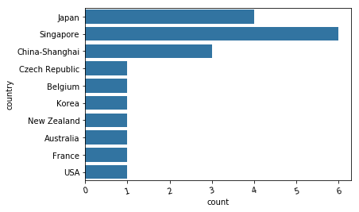

```python
sns.countplot(data= df_top10, y = 'country',  color = base_color)
plt.xticks(rotation = 15);
```

Let's check at the score distribution for 10 selected countries

```python
ten_countries = ['USA', 'China-Shanghai', 'Japan', 'Brazil', 'Singapore', 'Germany', 'France', 'Australia', 'Korea', 'United Kingdom']
df10_countries = df2.loc[df2['country'].isin(ten_countries)]
```

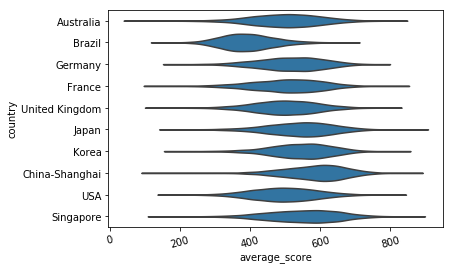

```python
sns.violinplot(data=df10_countries, x= 'average_score', y = 'country', inner = None, color = base_color)
plt.xticks(rotation = 15);
```

That's a surprise! Although OECD countries do better on average, the top 20 average scores are dominated by ASian countries

### Do students who play chess do better at math? What about at reading?

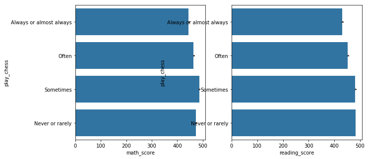

```python
plt.figure(figsize=[16,5])

plt.subplot(1,3,1)
sns.barplot(data = df2, x = 'math_score', y = 'play_chess', order = xorder, color = base_color)

plt.subplot(1,3,2)
sns.barplot(data = df2, x = 'reading_score', y = 'play_chess', order = xorder, color = base_color);
```

This is very counter-intuitive! one would normally have the prejudice that people who play chess are usually good at math. But this visualization suggests that those who always play chess have, on average, lower test scores in math. Who would have known?

### Do children with agency do better at the PISA test?

within this context, the variable agency is "Perceived Control - Doing Well is Completely Up to Me"

```python
df2.agency.value_counts()
```

```
Agree                138699
Strongly agree       127348
Disagree              40871
Strongly disagree      7264
Name: agency, dtype: int64
```

```python
agency_order = ['Strongly disagree', 'Disagree', 'Agree', 'Strongly agree']
```

```python
df2[df2.agency == 'Disagree']['average_score'].mean()
```

```
485.86458458320266
```

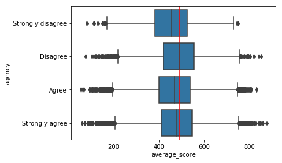

```python
sns.boxplot(data = df2, x = 'average_score', y = 'agency', order = agency_order, color = base_color)
plt.axvline(df2[df2.agency == 'Disagree']['average_score'].median(), color = 'r');
```

The evidence seems mixed. On the one hand, those who strongly disagree with the question "Doing well is completely up to Me" seem to be the group that does worse. On the other hand, the median student who disagreed with that statement tends to do better than any other group.

### Do students who do well in one category tend to do well on the other two?

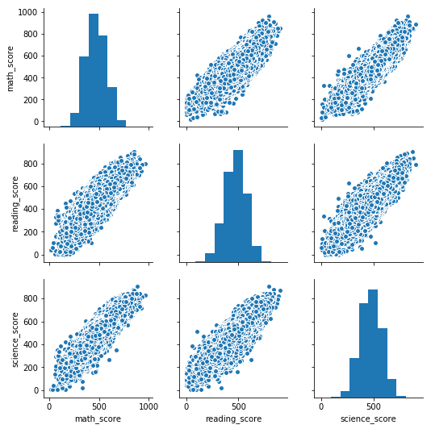

```python
sns.pairplot(df2[['math_score', 'reading_score', 'science_score']]);
```

There seems to be a clear linear relationship between the three scores, meaning that students thzt do well in one score tend to do better on the others.

## Multivariate Exploration

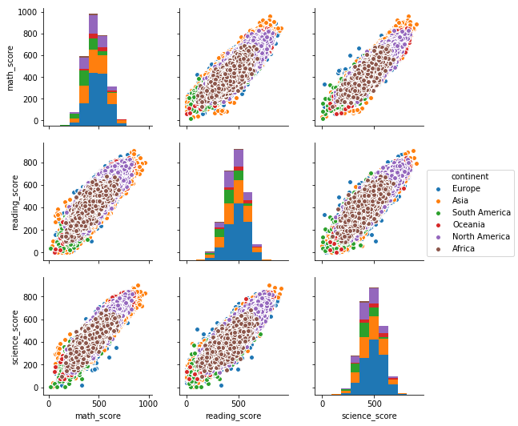

```python
sns.pairplot(df2[['math_score', 'reading_score', 'science_score', 'continent']], hue = 'continent');
```

This might not have been my best idea. This graph is too charged and does not give us any important insights

### Deep dive into agency -- what if we control for studying (math) or parents ed?

```python
df2[['agency','average_score']].groupby('agency').mean().max()
```

```
average_score    485.864585
dtype: float64
```

```python
for a in xorder:
    print(df2[df2.two_hours_math == a][['agency','average_score']].groupby('agency').mean().max())
```

```
average_score    439.829676
dtype: float64
average_score    462.920515
dtype: float64
average_score    484.573343
dtype: float64
average_score    495.380361
dtype: float64
```

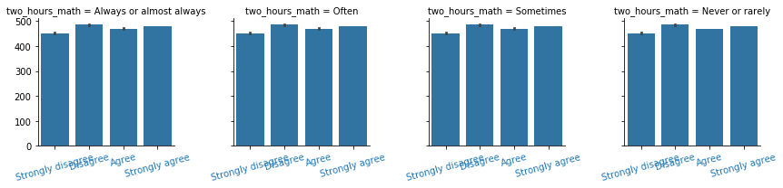

```python
g = sns.FacetGrid(data = df2, col = 'two_hours_math', col_order = xorder)
g.map(sns.barplot, data = df2, x = 'agency', y = 'average_score', order = agency_order)
g.map(plt.xticks, rotation = 15);
```

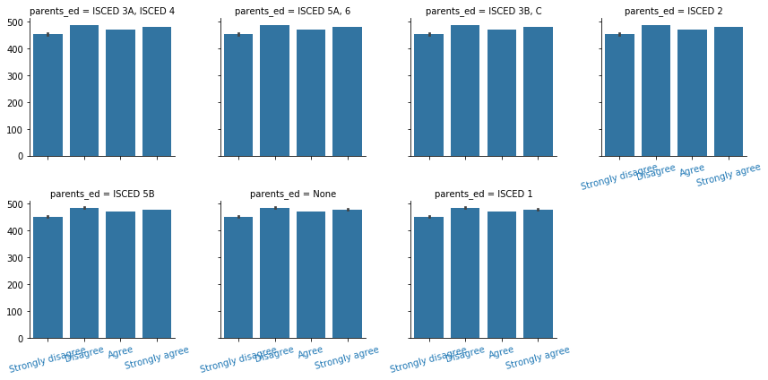

```python
g = sns.FacetGrid(data = df2, col = 'parents_ed', col_wrap = 4)
g.map(sns.barplot, data = df2, x = 'agency', y = 'average_score', order = agency_order)
g.map(plt.xticks, rotation = 15);
```

It also holds for accounting for parents education

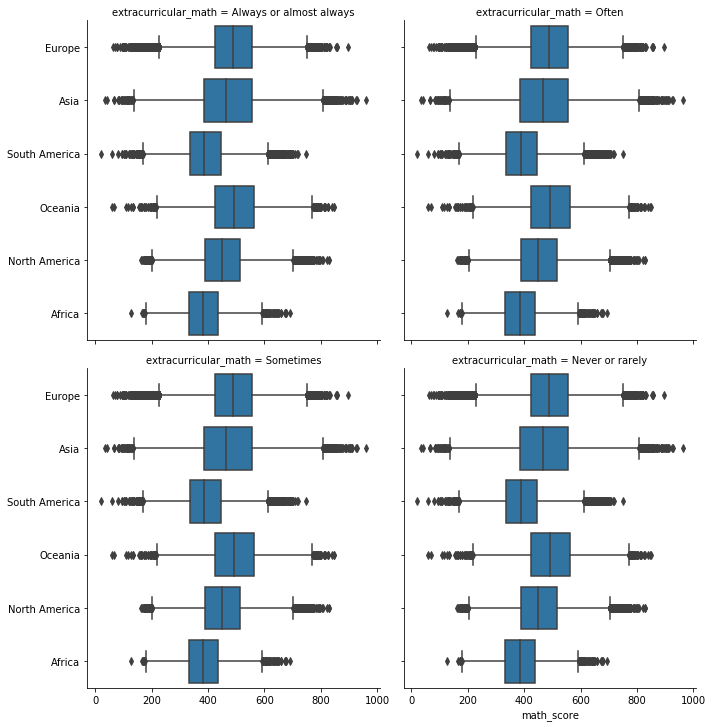

```python
g = sns.FacetGrid(data = df2, col = 'extracurricular_math', col_wrap = 2, col_order= xorder, size = 5)
g.map(sns.boxplot,data = df2, y = 'continent', x = 'math_score')
plt.xlabel('math_score');
```